# Chapter 3

Before performing simple linear regression we should import libraries and database

```python
import numpy as np
import pandas as pd
from matplotlib.pyplot import subplots
#import statsmodels.formula.api as smf
import statsmodels.api as sm
from ISLP import load_data
from ISLP.models import (ModelSpec as MS,summarize,poly)
#from scipy.stats import t
#from math import sqrt
import matplotlib.pyplot as plt
```

## Exercise 10

```python
Carseats=load_data('Carseats')
```

```python
# FYI
Carseats?
```

[output not shown]

[output cut: 88 more lines]

[output not shown]

```python
# FYI
dir(Carseats)
```

[output not shown]

[output cut: 373 more lines]

[output not shown]

```python
Carseats.info()
```

```
<class 'pandas.DataFrame'>
RangeIndex: 400 entries, 0 to 399
Data columns (total 11 columns):
 #   Column       Non-Null Count  Dtype
---  ------       --------------  -----
 0   Sales        400 non-null    float64
 1   CompPrice    400 non-null    int64
 2   Income       400 non-null    int64
 3   Advertising  400 non-null    int64
 4   Population   400 non-null    int64
 5   Price        400 non-null    int64
 6   ShelveLoc    400 non-null    category
 7   Age          400 non-null    int64
 8   Education    400 non-null    int64
 9   Urban        400 non-null    category
 10  US           400 non-null    category
dtypes: category(3), float64(1), int64(7)
memory usage: 26.4 KB
```

```python
Carseats.head()
```

|  | Sales | CompPrice | Income | Advertising | Population | Price | ShelveLoc | Age | Education | Urban | US |
| --- | --- | --- | --- | --- | --- | --- | --- | --- | --- | --- | --- |
| 0 | 9.50 | 138 | 73 | 11 | 276 | 120 | Bad | 42 | 17 | Yes | Yes |
| 1 | 11.22 | 111 | 48 | 16 | 260 | 83 | Good | 65 | 10 | Yes | Yes |
| 2 | 10.06 | 113 | 35 | 10 | 269 | 80 | Medium | 59 | 12 | Yes | Yes |
| 3 | 7.40 | 117 | 100 | 4 | 466 | 97 | Medium | 55 | 14 | Yes | Yes |
| 4 | 4.15 | 141 | 64 | 3 | 340 | 128 | Bad | 38 | 13 | Yes | No |

### (a)

```python
y=Carseats['Sales']
X=MS(Carseats[['Price','Urban','US']]).fit_transform(Carseats)
model=sm.OLS(y,X)
result=model.fit()
summarize(result)
```

|  | coef | std err | t | P>\|t\| |
| --- | --- | --- | --- | --- |
| intercept | 13.0435 | 0.651 | 20.036 | 0.000 |
| Price | -0.0545 | 0.005 | -10.389 | 0.000 |
| Urban[Yes] | -0.0219 | 0.272 | -0.081 | 0.936 |
| US[Yes] | 1.2006 | 0.259 | 4.635 | 0.000 |

### (b)

The coefficient related to the prdictor 'Urban' is statistically insignificant suggesting that there is no relationship between this latter and the response.  
The relationship between US and the response is positive. It means that when a store is located in the US, it will sell an average of 1200 more units approximately.  
On the other hand, the relationship with 'Price' is negative. That means that an increase in 1 dollar in the price will cause the sales to decrease by approximately 55 units.

### (d)

Through reading the p-values obtained in question (a) we can reject the null hypothesis for both predictors 'Price' and 'US' but not for 'Urban'.

### (e)

```python
Xnew=MS(Carseats[['Price','US']]).fit_transform(Carseats)
model_new=sm.OLS(y,Xnew)
result_new=model_new.fit()
summarize(result_new)
```

|  | coef | std err | t | P>\|t\| |
| --- | --- | --- | --- | --- |
| intercept | 13.0308 | 0.631 | 20.652 | 0.0 |
| Price | -0.0545 | 0.005 | -10.416 | 0.0 |
| US[Yes] | 1.1996 | 0.258 | 4.641 | 0.0 |

### (f)

To answer this question we can use the $R^2$ coefficient.

```python
print(" The R-squared for the regression model without Urban is ",result_new.rsquared)
print(" The R-squared for the regression model with Urban is ",result.rsquared)
```

```
 The R-squared for the regression model without Urban is  0.23926288842678567
 The R-squared for the regression model with Urban is  0.23927539218405525
```

We infer that the two models have almost identical $R^2$ values. However we must prefer the later model as it has a lower number of predictors.

### (g)

```python
result_new.conf_int(alpha=0.05)
```

|  | 0 | 1 |
| --- | --- | --- |
| intercept | 11.79032 | 14.271265 |
| Price | -0.06476 | -0.044195 |
| US[Yes] | 0.69152 | 1.707766 |

## Exercise 15

```python
Boston=load_data('Boston')
```

```python
Boston.columns
```

```
Index(['crim', 'zn', 'indus', 'chas', 'nox', 'rm', 'age', 'dis', 'rad', 'tax',
       'ptratio', 'lstat', 'medv'],
      dtype='str')
```

```python
Boston.head()
```

|  | crim | zn | indus | chas | nox | rm | age | dis | rad | tax | ptratio | lstat | medv |
| --- | --- | --- | --- | --- | --- | --- | --- | --- | --- | --- | --- | --- | --- |
| 0 | 0.00632 | 18.0 | 2.31 | 0 | 0.538 | 6.575 | 65.2 | 4.0900 | 1 | 296 | 15.3 | 4.98 | 24.0 |
| 1 | 0.02731 | 0.0 | 7.07 | 0 | 0.469 | 6.421 | 78.9 | 4.9671 | 2 | 242 | 17.8 | 9.14 | 21.6 |
| 2 | 0.02729 | 0.0 | 7.07 | 0 | 0.469 | 7.185 | 61.1 | 4.9671 | 2 | 242 | 17.8 | 4.03 | 34.7 |
| 3 | 0.03237 | 0.0 | 2.18 | 0 | 0.458 | 6.998 | 45.8 | 6.0622 | 3 | 222 | 18.7 | 2.94 | 33.4 |
| 4 | 0.06905 | 0.0 | 2.18 | 0 | 0.458 | 7.147 | 54.2 | 6.0622 | 3 | 222 | 18.7 | 5.33 | 36.2 |

### (a)

```python
# FYI
sm.add_constant?
```

[output not shown]

```python
result=[]
y=Boston['crim']
for i in range(1,13,1):
    predictor=Boston.columns[i]
    x=Boston.loc[:,predictor]
    x=sm.add_constant(x) # For intercept
    model=sm.OLS(y,x)
    result.append({predictor: model.fit().pvalues.iloc[1]})
result
```

```
[{'zn': np.float64(5.5064721076791945e-06)},
 {'indus': np.float64(1.450348933027281e-21)},
 {'chas': np.float64(0.20943450153520096)},
 {'nox': np.float64(3.7517392603567345e-23)},
 {'rm': np.float64(6.346702984687838e-07)},
 {'age': np.float64(2.8548693502440745e-16)},
 {'dis': np.float64(8.519948766926326e-19)},
 {'rad': np.float64(2.6938443981864414e-56)},
 {'tax': np.float64(2.357126835256745e-47)},
 {'ptratio': np.float64(2.9429224473599125e-11)},
 {'lstat': np.float64(2.6542772314732725e-27)},
 {'medv': np.float64(1.1739870821943694e-19)}]
```

```python
# FYI
result.append?
```

```
Signature: result.append(object, /)
Docstring: Append object to the end of the list.
Type:      builtin_function_or_method
```

All predictors are significant except 'chas'.

### (b)

```python
X=MS(Boston.columns.drop(['crim'])).fit_transform(Boston)
model=sm.OLS(y,X)
result_new=model.fit()
summarize(result_new)
```

|  | coef | std err | t | P>\|t\| |
| --- | --- | --- | --- | --- |
| intercept | 13.7784 | 7.082 | 1.946 | 0.052 |
| zn | 0.0457 | 0.019 | 2.433 | 0.015 |
| indus | -0.0584 | 0.084 | -0.698 | 0.486 |
| chas | -0.8254 | 1.183 | -0.697 | 0.486 |
| nox | -9.9576 | 5.290 | -1.882 | 0.060 |
| rm | 0.6289 | 0.607 | 1.036 | 0.301 |
| age | -0.0008 | 0.018 | -0.047 | 0.962 |
| dis | -1.0122 | 0.282 | -3.584 | 0.000 |
| rad | 0.6125 | 0.088 | 6.997 | 0.000 |
| tax | -0.0038 | 0.005 | -0.730 | 0.466 |
| ptratio | -0.3041 | 0.186 | -1.632 | 0.103 |
| lstat | 0.1388 | 0.076 | 1.833 | 0.067 |
| medv | -0.2201 | 0.060 | -3.678 | 0.000 |

The null hypothesis given in the question is rejected for the following predictors : zn, dis, rad and medv

### (c)

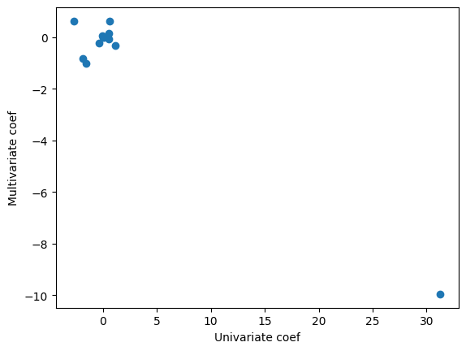

```python
result1=[]
for i in range(1,13,1):
    predictor=Boston.columns[i]
    x=Boston.loc[:,predictor]
    x=sm.add_constant(x)
    model1=sm.OLS(y,x)
    result1.append(model1.fit().params.iloc[1])
plt.scatter(result1,result_new.params[1:14])
plt.xlabel('Univariate coef')
plt.ylabel('Multivariate coef');
```

```python
result_new.pvalues[2:]
```

```
indus      4.857094e-01
chas       4.858406e-01
nox        6.036986e-02
rm         3.007385e-01
age        9.623231e-01
dis        3.725942e-04
rad        8.588123e-12
tax        4.657565e-01
ptratio    1.033932e-01
lstat      6.739844e-02
medv       2.605302e-04
dtype: float64
```

We notice that the outlier point returns to the 'Nox' coefficient. Let's remove this point from the plot and show it again

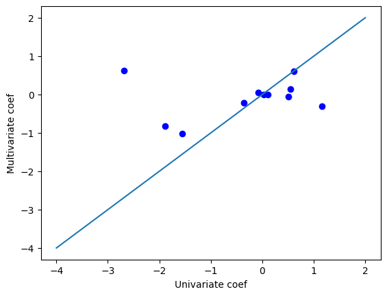

```python
plt.scatter(result1[0:3],result_new.params[1:4],color='blue')
plt.scatter(result1[4:12],result_new.params[5:14],color='blue')
plt.plot([-4,2], [-4,2])
plt.xlabel('Univariate coef')
plt.ylabel('Multivariate coef');
```

```python
df=pd.DataFrame({'Univariate':result1,'Multivariate':result_new.params[1:]})
```

```python
df
```

|  | Univariate | Multivariate |
| --- | --- | --- |
| zn | -0.073935 | 0.045710 |
| indus | 0.509776 | -0.058350 |
| chas | -1.892777 | -0.825378 |
| nox | 31.248531 | -9.957587 |
| rm | -2.684051 | 0.628911 |
| age | 0.107786 | -0.000848 |
| dis | -1.550902 | -1.012247 |
| rad | 0.617911 | 0.612465 |
| tax | 0.029742 | -0.003776 |
| ptratio | 1.151983 | -0.304073 |
| lstat | 0.548805 | 0.138801 |
| medv | -0.363160 | -0.220056 |

We notice that features 'age', 'rad', 'tax', 'medv' and 'zn' are the closer to the fitting line. However, since we failed to reject the null hyoptheses for 'age' and 'tax' their related points should have no meaning.

### (d)

```python
nl_results=[]
for i in range(1,13):
    predictor=Boston.columns[i]
    x=Boston.loc[:,predictor]
    X = MS([poly(predictor, degree=3)]).fit_transform(Boston)
    model=sm.OLS(y,X)
    nl_results.append({predictor:model.fit().pvalues[0:4]})
nl_results
```

```
[{'zn': intercept                1.547150e-20
  poly(zn, degree=3)[0]    4.697806e-06
  poly(zn, degree=3)[1]    4.420507e-03
  poly(zn, degree=3)[2]    2.295386e-01
  dtype: float64},
 {'indus': intercept                   3.606468e-25
  poly(indus, degree=3)[0]    8.854243e-24
  poly(indus, degree=3)[1]    1.086057e-03
  poly(indus, degree=3)[2]    1.196405e-12
  dtype: float64},
 {'chas': intercept                  0.63507
  poly(chas, degree=3)[0]    0.63507
  poly(chas, degree=3)[1]    0.63507
  poly(chas, degree=3)[2]    0.63507
  dtype: float64},
 {'nox': intercept                 2.742908e-26
  poly(nox, degree=3)[0]    2.457491e-26
  poly(nox, degree=3)[1]    7.736755e-05
  poly(nox, degree=3)[2]    6.961110e-16
  dtype: float64},
 {'rm': intercept                1.026665e-20
  poly(rm, degree=3)[0]    5.128048e-07
  poly(rm, degree=3)[1]    1.508545e-03
  poly(rm, degree=3)[2]    5.085751e-01
  dtype: float64},
 {'age': intercept                 5.918933e-23
  poly(age, degree=3)[0]    4.878803e-17
  poly(age, degree=3)[1]    2.291156e-06
  poly(age, degree=3)[2]    6.679915e-03
  dtype: float64},
 {'dis': intercept                 1.060226e-25
  poly(dis, degree=3)[0]    1.253249e-21
  poly(dis, degree=3)[1]    7.869767e-14
  poly(dis, degree=3)[2]    1.088832e-08
  dtype: float64},
 {'rad': intercept                 5.149845e-30
  poly(rad, degree=3)[0]    1.053211e-56
  poly(rad, degree=3)[1]    9.120558e-03
  poly(rad, degree=3)[2]    4.823138e-01
  dtype: float64},
 {'tax': intercept                 8.955923e-29
  poly(tax, degree=3)[0]    6.976314e-49
  poly(tax, degree=3)[1]    3.665348e-06
  poly(tax, degree=3)[2]    2.438507e-01
  dtype: float64},
 {'ptratio': intercept                     1.270767e-21
  poly(ptratio, degree=3)[0]    1.565484e-11
  poly(ptratio, degree=3)[1]    2.405468e-03
  poly(ptratio, degree=3)[2]    6.300514e-03
  dtype: float64},
 {'lstat': intercept                   4.939398e-24
  poly(lstat, degree=3)[0]    1.678072e-27
  poly(lstat, degree=3)[1]    3.780418e-02
  poly(lstat, degree=3)[2]    1.298906e-01
  dtype: float64},
 {'medv': intercept                  7.024110e-31
  poly(medv, degree=3)[0]    4.930818e-27
  poly(medv, degree=3)[1]    2.928577e-35
  poly(medv, degree=3)[2]    1.046510e-12
  dtype: float64}]
```

Cubic relationships are not significant for predictors 'rm', 'lstat', 'tax', 'rad', and 'chas'. On the other hand, features like 'indus', 'nox', 'age', 'dis', 'ptratio', and 'medv' do show significant cubic effects.